# Quantitative Genetics

Introduction to ASREML-R

Felipe Ferrão

University of Florida – July, 2022

**Objectives:**

- 20 minutes of hands-on
- Introduction ASREML-R

**Extra information**

- [PCB 65555 – Website](https://lfelipe-ferrao.github.io/class/quantGenetic/)
- About the [author](https://lfelipe-ferrao.github.io/)
- About the [UF/IFAS Plant Breeding](https://programs.ifas.ufl.edu/plant-breeding/)

# Introduction

In the previous class we explored the use of linear models and REML methods for variance component estimation. Although we opted to not present equations, estimating variance-covariance components in a mixed model context involves a deep understanding in matrix algebra, first derivatives and optimization methods. With the advent of new computational tools this process became less complex and currently breeders/geneticists can focus on the modeling steps per se, using the machinery of some well-established packages/software to implement mixed model.

Below we present a list of computational tools that summarize the computer packages that use REML as their core algorithm and some relevant features. More details are discussed by [Covarrubias-Pazaran, 2022](https://www.amazon.com/Complex-Trait-Prediction-Protocols-Molecular/dp/1071622048) in the Chapter 6 of the book Complex Trait Prediction.

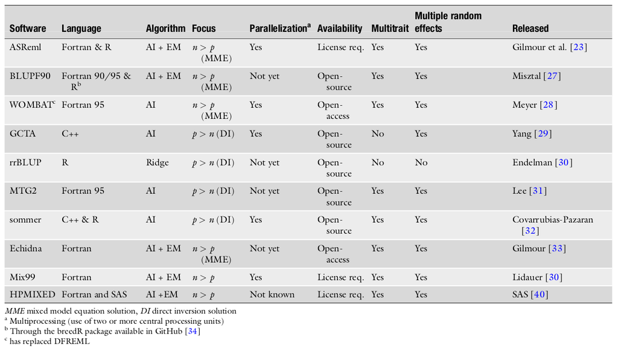

# Theory

## ASREML-R

An introduction about Asreml-R is presented [here](https://emitanaka.org/). Herein, we will present some general notes:

- ASReml is a commercial software that fit linear mixed models using REML with average information (AI) algorithm.
- ASReml refers to the standalone software with the core written in Fortran. While ASReml-R refers to the R-package that reads the output from ASReml-SA back into R.
- Asreml-r requires a license from [VSN International](https://www.vsni.co.uk/software/asreml)
- Basic syntax structure of ASReml-R:

```
asreml(response ~ fixed_expr, random=~ random_expr, rcov=~ rcov_expr)
```

- Random effects are specified in the argument `random`
- Residual effects are specified in the argument `rcov`

**Example**

```
library(asreml)
fit1 <- asreml(Yield ~ Site, random=~ Site:Geno, data = dat)
```

- `Site` is a fixed effect
- `Site:Geno` is the interaction effect
- `summary(fit1)`: large list with all results from the fitted model
- `summary(fit1)$varcomp`: variance parameter estimates
- `coef(fit1)$fixed`: fixed effects (eBLUE) for site
- `coef(fit1)$random`: random effects (eBLUP) for the interaction
- `data`: should be presented as a data.frame

**Some functions**

- `plot(fit1)`: we can plot the diagnostic of the model
- `wald(fit1)`: inference for fixed effects (Wald Test)
- `lrt(fit2,fit1)`: residual likelihood test to compare to nested models
- `predict(fit1,classify="Geno")$predictions$pval`: predict the adjusted means for fixed and random terms

**Convergence issues**

- `update(fit1)`: run more iterations to archive the convergence
- Decrease the `stepsize=0.01` in the argument of the `asreml` function
- Use initial values (`init`) in the argument of the `asreml` function

**Some important tips for memory space**

- Try to increase the `workspace="10gb"`, when fitting LMM using the `asreml` function
- Increase the `pworkspace="10gb"` when using the `predict` function
- Be careful to check your system monitor to track your RAM memory

## More details on goodness-of-fit

Testing the importance of some source of variation in a model is common in any statistical analyses to make inference. For example, in the ANOVA context, we can check the importance of the genotypic effect by contrasting with the residual using the F test. In a similar way, I could fit a model contemplating the genotypic effect (here called as **ful model**) and an alternative model without the genotypic effect (**reduced model**). Intuition behind is not complex, if the genotypic effect is an important source of variation in the data set, when we compare full vs. reduced model, we will differences in the goodness-of-fit of the model.

But how to compare the goodness-of-fit statistics? Here, we need remember some concepts, including the likelihood. Technically, a likelihood function is the joint probability of the observed data viewed as a function of the parameters of the chosen statistical model. Hence, how well a sample provides support for particular values of a parameter in a model. In another words, intuitively we can imagine that, if the inclusion of the genotypic effect (i.e, full model) can provides more support to explain the phenotypic variation, the full model will have higher likelihood than the reduced model and therefore should be considered. This job is done by the **likelihood-ratio test**

$$LRT = -2 ln
\dfrac{L_{red}}{L_{full}}$$

- The likelihood-ratio test assesses the goodness of fit of two competing statistical models based on the ratio of their likelihoods, specifically one found by maximization over the entire parameter space and another found after imposing some constraint. If the constraint (i.e., the null hypothesis) is supported by the observed data, the two likelihoods should not differ by more than sampling error.[1] Thus the likelihood-ratio test tests whether this ratio is significantly different from one, or equivalently whether its natural logarithm is significantly different from zero [ref](https://en.wikipedia.org/wiki/Likelihood-ratio_test).

Good news about the LRT is because its statistic follows an approximated $\chi^2$ distribution with degrees of freedom equal to the difference in the number of estimated variance components between both models. So, at the end of the analyses, we can draw conclusions based on a p.valor (i.e, when the pvalue is very small we have statistics evidences that both models are differences and therefore we should choose the model with higher likelihood associated).

In `asreml-R`, we can use the following function to run the LRT:

```
lrt.asreml(null_model, full_model, boundary=FALSE),
```

Another important metric to compare models is the AIC and BIC. An important assumption for LRT is that both models are nested. When this is not the case, the most common ones used for LMMs are the Akaike Information Criterion (AIC), and the Bayesian Information Criterion (BIC):

$$AIC=-2 \times logL + 2 \times
t$$

# Hands-on

For the hands-on, we will use the same data set used in the introduction to mixed model class.

- Download the Maize Recombination Inbred Lines Data (`MaizeRILS.csv`), an example from [Isik et al., 2017](https://www.springer.com/gp/book/9783319551753).
  - [Link for the example](https://drive.google.com/drive/folders/0B9JWAJgh6v3Cflppc09XUXU3WHRvX29qY1IxNDVFaEdpblA4SFNXOThQV2ZDRVkxWlZWSEk).
  - Description: 62 recombinat inbreed lines (RIL) progeny from the crosses between inbred maize lines B73 and MO17. RILS were grown in experimental units using a RCBD design with two replications and four locations.

```r
library(dplyr)
library(asreml)
# Download the data
maize = read.csv("/home/lferrao/Dropbox (UFL)/classes/QuantitativeGenetics_22/Class3_MixedModelsAsReml/MaizeRILs.csv")
maize$rep = as.factor(maize$rep)
maize$block = as.factor(maize$block)

# ASREML fixed model
m3 = asreml(height ~ rep:location + RIL*location,            data=maize)
```

```
## Model fitted using the gamma parameterization.
## ASReml 4.1.0 Wed Oct  5 08:49:51 2022
##           LogLik        Sigma2     DF     wall    cpu
##  1      -723.880       64.8862    244 08:49:51    0.0
```

```r
wald(m3)
```

```
## Wald tests for fixed effects.
## Response: height
## Terms added sequentially; adjusted for those above.
##
##                Df Sum of Sq Wald statistic Pr(Chisq)
## (Intercept)     1  16451084         253537 < 2.2e-16 ***
## RIL            61    154938           2388 < 2.2e-16 ***
## location        3     84931           1309 < 2.2e-16 ***
## rep:location    4      3594             55 2.688e-11 ***
## RIL:location  183     20999            324 6.889e-10 ***
## residual (MS)            65
## ---
## Signif. codes:  0 '***' 0.001 '**' 0.01 '*' 0.05 '.' 0.1 ' ' 1
```

```r
# ASREML random model
m4 = asreml(height ~ rep:location + location,
            random= ~RIL  + RIL:location ,
            data=maize)
```

```
## Model fitted using the gamma parameterization.
## ASReml 4.1.0 Wed Oct  5 08:49:52 2022
##           LogLik        Sigma2     DF     wall    cpu
##  1     -1622.074       227.050    488 08:49:52    0.0
##  2     -1547.385       136.365    488 08:49:52    0.0
##  3     -1487.565        94.254    488 08:49:52    0.0
##  4     -1456.664        77.092    488 08:49:52    0.0
##  5     -1444.756        68.620    488 08:49:52    0.0
##  6     -1442.763        65.660    488 08:49:52    0.0
##  7     -1442.651        64.940    488 08:49:52    0.0
##  8     -1442.650        64.887    488 08:49:52    0.0
```

```r
summary(m4)
```

```
## $call
## asreml(fixed = height ~ rep:location + location, random = ~RIL +
##     RIL:location, data = maize)
##
## $loglik
## [1] -1442.65
##
## $nedf
## [1] 488
##
## $sigma
## [1] 8.055218
##
## $varcomp
##              component std.error   z.ratio bound %ch
## RIL          303.15255 57.505933  5.271674     P   0
## RIL:location  24.93243  6.678744  3.733101     P   0
## units!R       64.88654  5.874566 11.045334     P   0
##
## $bic
## [1] 2903.871
## attr(,"parameters")
## [1] 3
##
## $aic
## [1] 2891.3
## attr(,"parameters")
## [1] 3
##
## attr(,"class")
## [1] "summary.asreml"
```

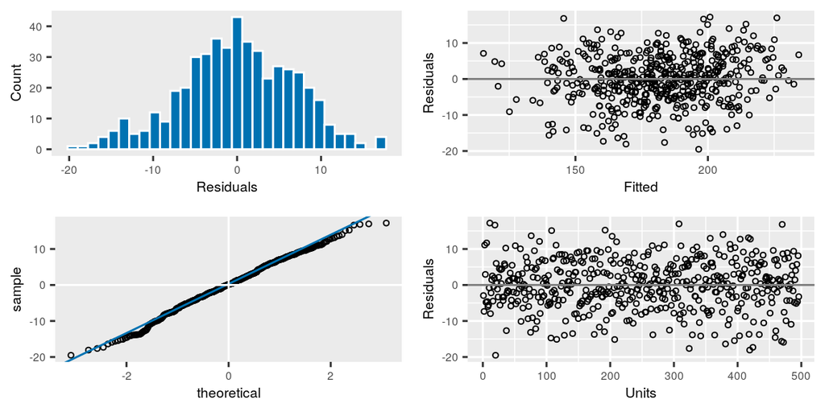

```r
plot(m4)
```

```r
wald(m4)
```

```
## Wald tests for fixed effects.
## Response: height
## Terms added sequentially; adjusted for those above.
##
##               Df Sum of Sq Wald statistic Pr(Chisq)
## (Intercept)    1    420278         6477.1 < 2.2e-16 ***
## location       3     48025          740.1 < 2.2e-16 ***
## rep:location   4      3594           55.4 2.688e-11 ***
## residual (MS)           65
## ---
## Signif. codes:  0 '***' 0.001 '**' 0.01 '*' 0.05 '.' 0.1 ' ' 1
```

```r
BLUPS = predict(m4,classify="RIL")
```

```
## Model fitted using the gamma parameterization.
## ASReml 4.1.0 Wed Oct  5 08:49:52 2022
##           LogLik        Sigma2     DF     wall    cpu
##  1     -1442.650       64.8862    488 08:49:52    0.0
##  2     -1442.650       64.8862    488 08:49:52    0.0
##  3     -1442.650       64.8862    488 08:49:52    0.0
```

```r
head(as.data.frame(BLUPS$pvals))
```

```
##      RIL predicted.value std.error    status
## 1  RIL-1        182.1005  2.811925 Estimable
## 2 RIL-11        182.8557  2.811925 Estimable
## 3 RIL-12        185.1213  2.811925 Estimable
## 4 RIL-14        193.9401  2.811925 Estimable
## 5 RIL-15        195.4262  2.811925 Estimable
## 6 RIL-16        173.0624  2.811925 Estimable
```

- Results using `lme4` and `asreml-r` are the equal
- In the sequence, we will discuss a group of advantages on using `asreml-r`, including the graphical diagnostics, possibility to test different var-cov structures for interaction studies and inclusion of pedigree information in animal models

# Conclusions

- We can estimate genetic parameters and fit linear mixed models using different software
- During the class, we will the `asreml-r`package, that presents some straightforward functions for estimation and visualization.